# Validation of GHACOF predictions

```r
knitr::opts_chunk$set(echo = FALSE)

# knitr::opts_chunk$set(fig.width = 6)
# knitr::opts_chunk$set(fig.height = 6)
```

## Goal:

- Put together a toolkit for evaluation of GHACOF-predictions.
- The toolkit will be in R (and possibly Python). It should be easy-to-use, self-contained and flexible.
- Communication between ICPAC and NR extremely important!
- Let's have (possibly short) meetings every other week.
- How are ICPACs data formats now, in the past and in the future?

## Proper scoring rules for tercile forecasts

- Proper scoring rules are tools for evaluating predictive performance. Lower scores indicate better performance.
- **Examples:** Brier Score, Mean Square Error, Log-likelihood score or the continuous ranked probability score (CRPS).
- For tercile forecasts: The *ranked probability score (RPS)* is defined as \[\text{RPS} := \big( (p_1 - e_1)^2 + (p_2 - e_2)^2 + (p_3 - e_3)^2\big).\] Here, \(p_1,p_2,\) and \(p_3\) are the predicted probabilities for the three categories, and \(e_i\) is 1 if the observation falls in the \(i\)th category, and 0 else.
- For example, if the observation falls into the first category, the RPS would be \[(p_1 - 1)^2 + p_2^2 + p_3^2.\]
- The RPS is *proper*, meaning that it rewards calibration and accuracy.
- The climatological forecast always gets an RPS of 2/3 = 0.67.
- We can spatially average: E.g. if we average the RPS of our prediction over all gridpoints in Ethiopia and obtain a value below 2/3, our prediction for Ethiopia was on average better than climatology.

**Data example:** the seasonal prediction issued January 2021 for the time period FMA *(from the ICPAC repository ~/SharedData/gcm/seasonal/202101/).*

```
##        Lon   Lat     below    normal     above
##    1: 22.0 -11.0 0.3627303 0.2294653 0.4078045
##    2: 22.5 -11.0 0.3581976 0.2231329 0.4186695
##    3: 23.0 -11.0 0.3686610 0.1868641 0.4444749
##    4: 23.5 -11.0 0.3713619 0.1959593 0.4326788
##    5: 24.0 -11.0 0.3738705 0.1762815 0.4498480
##   ---
## 3046: 49.0  22.5 0.3033419 0.2058225 0.4908356
## 3047: 49.5  22.5 0.3356672 0.1508025 0.5135303
## 3048: 50.0  22.5 0.3504115 0.1507126 0.4988759
## 3049: 50.5  22.5 0.3473273 0.1785831 0.4740896
## 3050: 51.0  22.5 0.3703094 0.1681518 0.4615388
```

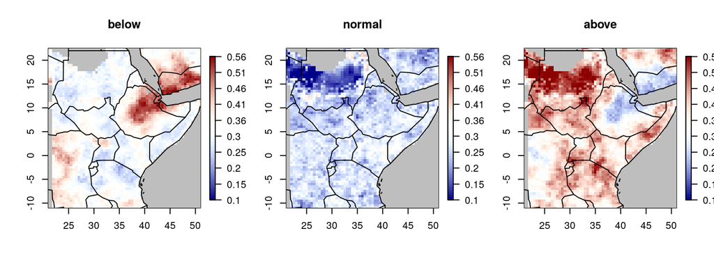

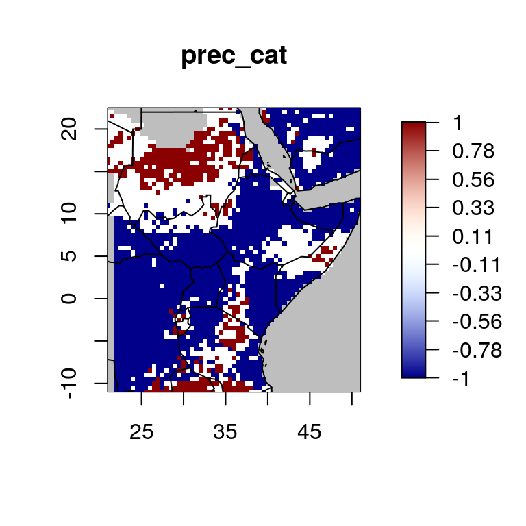

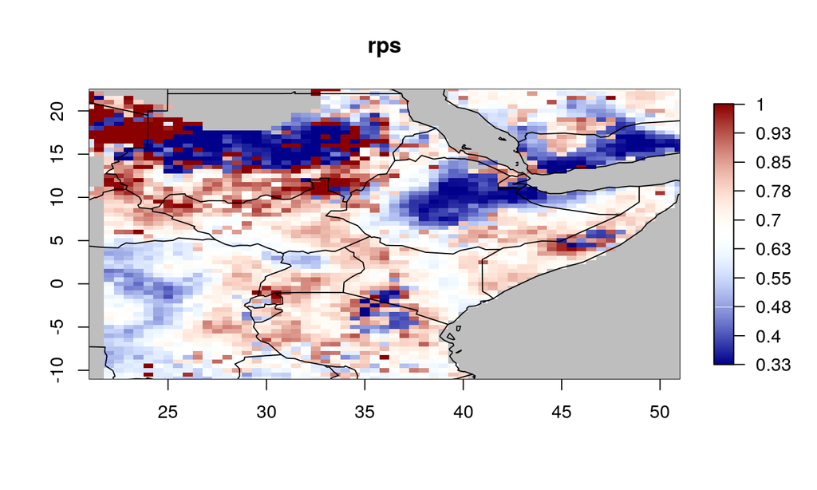

```
## [1] NA
```

## Why evaluate all three probabilities, not only the most likely category?

- Proper scores that are only based on the highest probability category are difficult to construct.
- Intuitively, a promising candidate seems to be the Brier Score \[BS_{\max} = (p_{\max}-e_{\max})^2,\] where \(p_{\max}\) is the probability assigned to the maximum probability category, and \(e_{\max} = 1\) if the observation falls into that category and \(0\) else.
- Unfortunately, it turns out that this score is *improper*: it does not reward calibration and accuracy. Let us look at an example forecast for just one gridpoint:

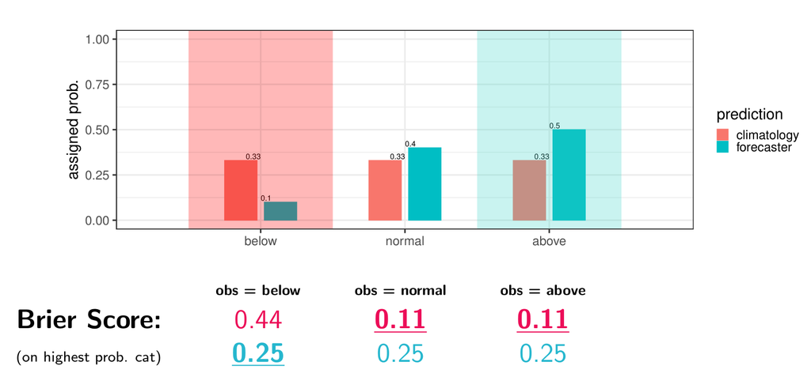

- The only proper score we are aware of, that is only based on the highest probability category, is the hit-score \[HS := 1-e_{\max}\] (returns 0 when the observation falls into the category whith the highest predicted probability category, and 1 else.)
- takes only two values, so contains much less information than the RPS is evaluated.
- There is nothing wrong with evaluating the full probability vector \((p_1,p_2,p_3)\), but only communicating the highest of the three probabilities to the public.